# Assignment 4-Clustering

VARSHITHA GUDURU

2024-03-17

```r
knitr::opts_chunk$set(echo = TRUE, comment = NA)
```

An equities analyst is studying the pharmaceutical industry and would like your help in exploring and understanding the financial data collected by her firm. Her main objective is to understand the structure of the pharmaceutical industry using some basic financial measures. Financial data gathered on 21 firms in the pharmaceutical industry are available in the file Pharmaceuticals.csv

Use cluster analysis to explore and analyze the given dataset

```r
library(factoextra)
```

```r
library(ggplot2)
library(tidyverse)
library(readr)

Pharmaceuticals <- read.csv("C:/Users/Varshitha/Downloads/Pharmaceuticals (1).csv")

summary(Pharmaceuticals)
```

```
    Symbol              Name             Market_Cap          Beta
 Length:21          Length:21          Min.   :  0.41   Min.   :0.1800
 Class :character   Class :character   1st Qu.:  6.30   1st Qu.:0.3500
 Mode  :character   Mode  :character   Median : 48.19   Median :0.4600
                                       Mean   : 57.65   Mean   :0.5257
                                       3rd Qu.: 73.84   3rd Qu.:0.6500
                                       Max.   :199.47   Max.   :1.1100
    PE_Ratio          ROE            ROA        Asset_Turnover    Leverage
 Min.   : 3.60   Min.   : 3.9   Min.   : 1.40   Min.   :0.3    Min.   :0.0000
 1st Qu.:18.90   1st Qu.:14.9   1st Qu.: 5.70   1st Qu.:0.6    1st Qu.:0.1600
 Median :21.50   Median :22.6   Median :11.20   Median :0.6    Median :0.3400
 Mean   :25.46   Mean   :25.8   Mean   :10.51   Mean   :0.7    Mean   :0.5857
 3rd Qu.:27.90   3rd Qu.:31.0   3rd Qu.:15.00   3rd Qu.:0.9    3rd Qu.:0.6000
 Max.   :82.50   Max.   :62.9   Max.   :20.30   Max.   :1.1    Max.   :3.5100
   Rev_Growth    Net_Profit_Margin Median_Recommendation   Location
 Min.   :-3.17   Min.   : 2.6      Length:21             Length:21
 1st Qu.: 6.38   1st Qu.:11.2      Class :character      Class :character
 Median : 9.37   Median :16.1      Mode  :character      Mode  :character
 Mean   :13.37   Mean   :15.7
 3rd Qu.:21.87   3rd Qu.:21.1
 Max.   :34.21   Max.   :25.5
   Exchange
 Length:21
 Class :character
 Mode  :character
```

**Qustion (a):** Use only the numerical variables (1 to 9) to cluster the 21 firms. Justify the various choices made in conducting the cluster analysis, such as weights for different variables, the specific clustering algorithm(s) used, the number of clusters formed, and so on.

**Answer (a):** Remove missing data and rescale variables for comparability before grouping the data.

```r
x <- na.omit(Pharmaceuticals) #Doing this will remove all the missing values in the data
x
```

|  | Symbol | Name | Market_Cap | Beta | PE_Ratio | ROE | ROA | Asset_Turnover | Leverage | Rev_Growth | Net_Profit_Margin | Median_Recommendation | Location | Exchange |
| --- | --- | --- | --- | --- | --- | --- | --- | --- | --- | --- | --- | --- | --- | --- |
| 1 | ABT | Abbott Laboratories | 68.44 | 0.32 | 24.7 | 26.4 | 11.8 | 0.7 | 0.42 | 7.54 | 16.1 | Moderate Buy | US | NYSE |
| 2 | AGN | Allergan, Inc. | 7.58 | 0.41 | 82.5 | 12.9 | 5.5 | 0.9 | 0.60 | 9.16 | 5.5 | Moderate Buy | CANADA | NYSE |
| 3 | AHM | Amersham plc | 6.30 | 0.46 | 20.7 | 14.9 | 7.8 | 0.9 | 0.27 | 7.05 | 11.2 | Strong Buy | UK | NYSE |
| 4 | AZN | AstraZeneca PLC | 67.63 | 0.52 | 21.5 | 27.4 | 15.4 | 0.9 | 0.00 | 15.00 | 18.0 | Moderate Sell | UK | NYSE |
| 5 | AVE | Aventis | 47.16 | 0.32 | 20.1 | 21.8 | 7.5 | 0.6 | 0.34 | 26.81 | 12.9 | Moderate Buy | FRANCE | NYSE |
| 6 | BAY | Bayer AG | 16.90 | 1.11 | 27.9 | 3.9 | 1.4 | 0.6 | 0.00 | -3.17 | 2.6 | Hold | GERMANY | NYSE |
| 7 | BMY | Bristol-Myers Squibb Company | 51.33 | 0.50 | 13.9 | 34.8 | 15.1 | 0.9 | 0.57 | 2.70 | 20.6 | Moderate Sell | US | NYSE |
| 8 | CHTT | Chattem, Inc | 0.41 | 0.85 | 26.0 | 24.1 | 4.3 | 0.6 | 3.51 | 6.38 | 7.5 | Moderate Buy | US | NASDAQ |
| 9 | ELN | Elan Corporation, plc | 0.78 | 1.08 | 3.6 | 15.1 | 5.1 | 0.3 | 1.07 | 34.21 | 13.3 | Moderate Sell | IRELAND | NYSE |
| 10 | LLY | Eli Lilly and Company | 73.84 | 0.18 | 27.9 | 31.0 | 13.5 | 0.6 | 0.53 | 6.21 | 23.4 | Hold | US | NYSE |

[output cut: 11 more lines]

[output not shown]

Having now eliminated the missing values from the data, we should gather only the quantitative variables (i.e., 1–9) in order to group the 21 companies.

```r
row.names(x) <- x[,1]
Pharma1<- x[,3:11]
head(Pharma1)
```

|  | Market_Cap | Beta | PE_Ratio | ROE | ROA | Asset_Turnover | Leverage | Rev_Growth | Net_Profit_Margin |
| --- | --- | --- | --- | --- | --- | --- | --- | --- | --- |
| ABT | 68.44 | 0.32 | 24.7 | 26.4 | 11.8 | 0.7 | 0.42 | 7.54 | 16.1 |
| AGN | 7.58 | 0.41 | 82.5 | 12.9 | 5.5 | 0.9 | 0.60 | 9.16 | 5.5 |
| AHM | 6.30 | 0.46 | 20.7 | 14.9 | 7.8 | 0.9 | 0.27 | 7.05 | 11.2 |
| AZN | 67.63 | 0.52 | 21.5 | 27.4 | 15.4 | 0.9 | 0.00 | 15.00 | 18.0 |
| AVE | 47.16 | 0.32 | 20.1 | 21.8 | 7.5 | 0.6 | 0.34 | 26.81 | 12.9 |
| BAY | 16.90 | 1.11 | 27.9 | 3.9 | 1.4 | 0.6 | 0.00 | -3.17 | 2.6 |

[output not shown]

All of the quantitative variables in the dataframe are now scaled.

```r
Pharma2<-scale(Pharma1)
head(Pharma2)
```

```
    Market_Cap        Beta    PE_Ratio         ROE        ROA Asset_Turnover
ABT  0.1840960 -0.80125356 -0.04671323  0.04009035  0.2416121      0.0000000
AGN -0.8544181 -0.45070513  3.49706911 -0.85483986 -0.9422871      0.9225312
AHM -0.8762600 -0.25595600 -0.29195768 -0.72225761 -0.5100700      0.9225312
AZN  0.1702742 -0.02225704 -0.24290879  0.10638147  0.9181259      0.9225312
AVE -0.1790256 -0.80125356 -0.32874435 -0.26484883 -0.5664461     -0.4612656
BAY -0.6953818  2.27578267  0.14948233 -1.45146000 -1.7127612     -0.4612656
      Leverage Rev_Growth Net_Profit_Margin
ABT -0.2120979 -0.5277675        0.06168225
AGN  0.0182843 -0.3811391       -1.55366706
AHM -0.4040831 -0.5721181       -0.68503583
AZN -0.7496565  0.1474473        0.35122600
AVE -0.3144900  1.2163867       -0.42597037
BAY -0.7496565 -1.4971443       -1.99560225
```

The next stage is to calculate the number of clusters for the Elbow Method cluster analysis.

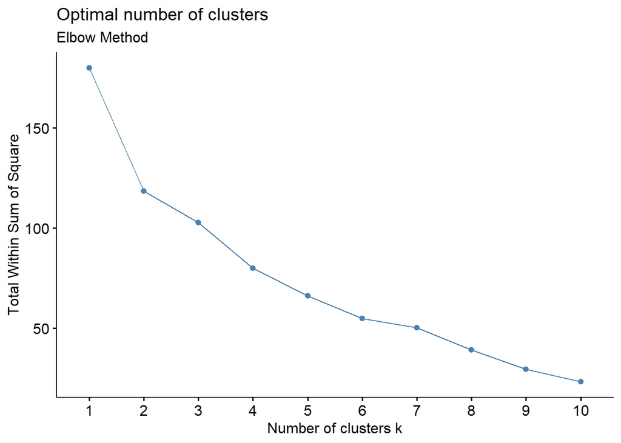

```r
fviz_nbclust(Pharma2, kmeans, method = "wss") + labs(subtitle = "Elbow Method")
```

Finding the number of clusters using the silhouette method

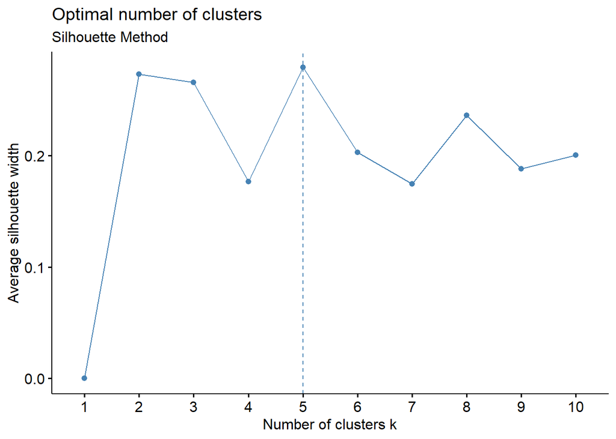

```r
fviz_nbclust(Pharma2, kmeans, method = "silhouette")+ labs(subtitle = "Silhouette Method")
```

```r
set.seed(120)
k5<- kmeans(Pharma2,centers=5,nstart = 25)
#Visualize the output
k5$centers  #centroids
```

```
   Market_Cap       Beta    PE_Ratio        ROE        ROA Asset_Turnover
1  1.69558112 -0.1780563 -0.19845823  1.2349879  1.3503431      1.1531640
2 -0.43925134 -0.4701800  2.70002464 -0.8349525 -0.9234951      0.2306328
3 -0.03142211 -0.4360989 -0.31724852  0.1950459  0.4083915      0.1729746
4 -0.87051511  1.3409869 -0.05284434 -0.6184015 -1.1928478     -0.4612656
5 -0.76022489  0.2796041 -0.47742380 -0.7438022 -0.8107428     -1.2684804
     Leverage Rev_Growth Net_Profit_Margin
1 -0.46807818  0.4671788       0.591242521
2 -0.14170336 -0.1168459      -1.416514761
3 -0.27449312 -0.7041516       0.556954446
4  1.36644699 -0.6912914      -1.320000179
5  0.06308085  1.5180158      -0.006893899
```

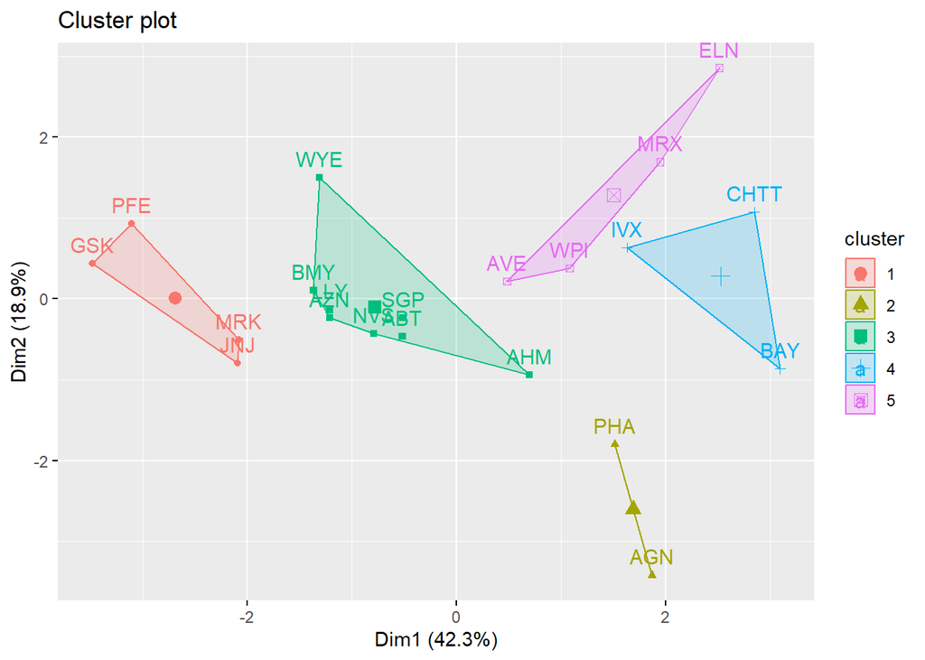

```r
fviz_cluster(k5,data = Pharma2) # to Visualize the clusters
```

```r
k5
```

```
K-means clustering with 5 clusters of sizes 4, 2, 8, 3, 4

Cluster means:
   Market_Cap       Beta    PE_Ratio        ROE        ROA Asset_Turnover
1  1.69558112 -0.1780563 -0.19845823  1.2349879  1.3503431      1.1531640
2 -0.43925134 -0.4701800  2.70002464 -0.8349525 -0.9234951      0.2306328
3 -0.03142211 -0.4360989 -0.31724852  0.1950459  0.4083915      0.1729746
4 -0.87051511  1.3409869 -0.05284434 -0.6184015 -1.1928478     -0.4612656
5 -0.76022489  0.2796041 -0.47742380 -0.7438022 -0.8107428     -1.2684804
     Leverage Rev_Growth Net_Profit_Margin
1 -0.46807818  0.4671788       0.591242521
2 -0.14170336 -0.1168459      -1.416514761
3 -0.27449312 -0.7041516       0.556954446
4  1.36644699 -0.6912914      -1.320000179
5  0.06308085  1.5180158      -0.006893899

Clustering vector:
 ABT  AGN  AHM  AZN  AVE  BAY  BMY CHTT  ELN  LLY  GSK  IVX  JNJ  MRX  MRK  NVS
   3    2    3    3    5    4    3    4    5    3    1    4    1    5    1    3
 PFE  PHA  SGP  WPI  WYE
   1    2    3    5    3

Within cluster sum of squares by cluster:
[1]  9.284424  2.803505 21.879320 15.595925 12.791257
 (between_SS / total_SS =  65.4 %)

Available components:

[1] "cluster"      "centers"      "totss"        "withinss"     "tot.withinss"
[6] "betweenss"    "size"         "iter"         "ifault"
```

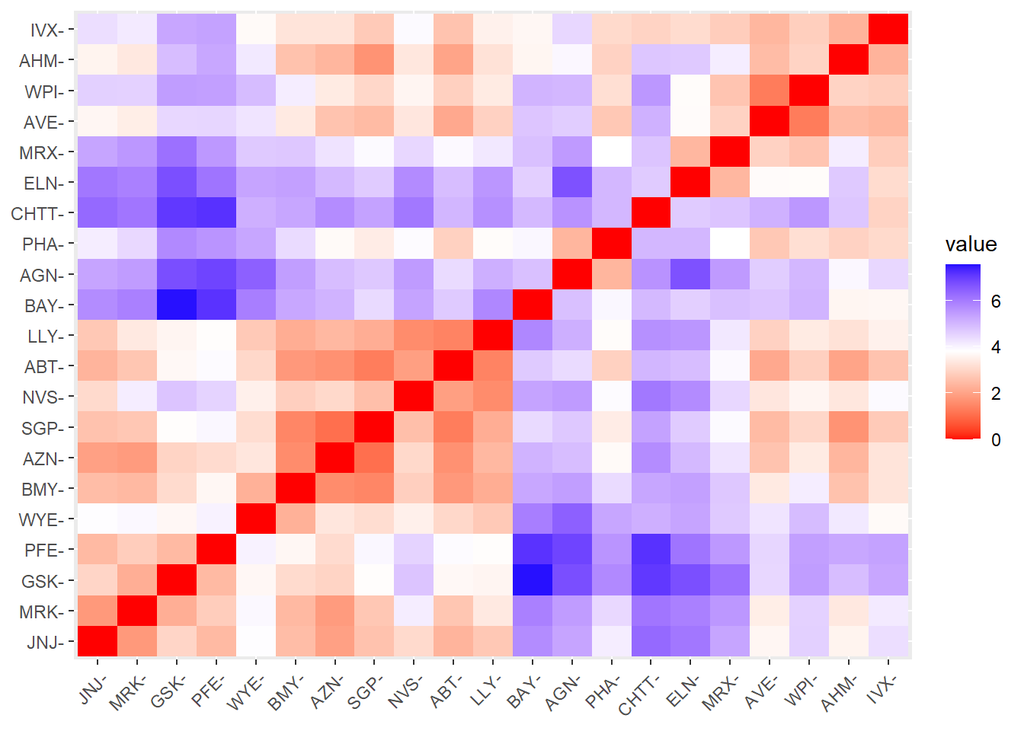

```r
distance<- dist(Pharma2, method = "euclidean")
fviz_dist(distance)
```

**K-Means Cluster Analysis** - Fit the data with 5 clusters

```r
fit<-kmeans(Pharma2,5)
```

Now, we find the mean value of all quantitative variables for each cluster

```r
aggregate(Pharma2,by=list(fit$cluster),FUN=mean)
```

| Group.1 | Market_Cap | Beta | PE_Ratio | ROE | ROA | Asset_Turnover | Leverage | Rev_Growth | Net_Profit_Margin |
| --- | --- | --- | --- | --- | --- | --- | --- | --- | --- |
| 1 | -0.87051511 | 1.3409869 | -0.05284434 | -0.6184015 | -1.1928478 | -4.612656e-01 | 1.3664470 | -0.6912914 | -1.3200002 |
| 2 | 0.08926902 | -0.4618336 | -0.32086149 | 0.3260892 | 0.5396003 | 6.589509e-02 | -0.2559803 | -0.7230135 | 0.7343816 |
| 3 | -0.96686975 | 1.5162611 | -0.57398880 | -0.8382671 | -0.9892673 | -1.845062e+00 | 0.5302448 | 1.7123890 | 0.2445520 |
| 4 | 1.69558112 | -0.1780563 | -0.19845823 | 1.2349879 | 1.3503431 | 1.153164e+00 | -0.4680782 | 0.4671788 | 0.5912425 |
| 5 | -0.57238455 | -0.6220844 | 0.86927480 | -0.7381675 | -0.7242993 | 1.776140e-16 | -0.2991312 | 0.3682951 | -0.8069490 |

[output not shown]

```r
Pharma3<-data.frame(Pharma2,fit$cluster)
Pharma3
```

|  | Market_Cap | Beta | PE_Ratio | ROE | ROA | Asset_Turnover | Leverage | Rev_Growth | Net_Profit_Margin | fit.cluster |
| --- | --- | --- | --- | --- | --- | --- | --- | --- | --- | --- |
| ABT | 0.1840960 | -0.80125356 | -0.04671323 | 0.04009035 | 0.2416121 | 0.0000000 | -0.21209793 | -0.52776752 | 0.06168225 | 2 |
| AGN | -0.8544181 | -0.45070513 | 3.49706911 | -0.85483986 | -0.9422871 | 0.9225312 | 0.01828430 | -0.38113909 | -1.55366706 | 5 |
| AHM | -0.8762600 | -0.25595600 | -0.29195768 | -0.72225761 | -0.5100700 | 0.9225312 | -0.40408312 | -0.57211809 | -0.68503583 | 5 |
| AZN | 0.1702742 | -0.02225704 | -0.24290879 | 0.10638147 | 0.9181259 | 0.9225312 | -0.74965647 | 0.14744734 | 0.35122600 | 2 |
| AVE | -0.1790256 | -0.80125356 | -0.32874435 | -0.26484883 | -0.5664461 | -0.4612656 | -0.31449003 | 1.21638667 | -0.42597037 | 5 |
| BAY | -0.6953818 | 2.27578267 | 0.14948233 | -1.45146000 | -1.7127612 | -0.4612656 | -0.74965647 | -1.49714434 | -1.99560225 | 1 |
| BMY | -0.1078688 | -0.10015669 | -0.70887325 | 0.59693581 | 0.8617498 | 0.9225312 | -0.02011273 | -0.96584257 | 0.74744375 | 2 |
| CHTT | -0.9767669 | 1.26308721 | 0.03299122 | -0.11237924 | -1.1677918 | -0.4612656 | 3.74279705 | -0.63276071 | -1.24888417 | 1 |
| ELN | -0.9704532 | 2.15893320 | -1.34037772 | -0.70899938 | -1.0174553 | -1.8450624 | 0.61983791 | 1.88617085 | -0.36501379 | 3 |
| LLY | 0.2762415 | -1.34655112 | 0.14948233 | 0.34502953 | 0.5610770 | -0.4612656 | -0.07130879 | -0.64814764 | 1.17413980 | 2 |

[output cut: 11 more lines]

[output not shown]

FOr viewing the cluster plot

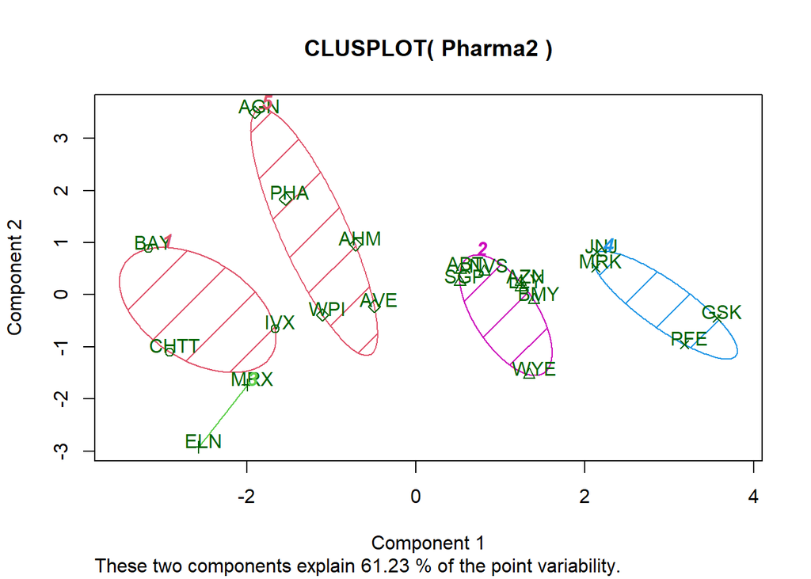

```r
library(cluster)
clusplot(Pharma2,fit$cluster,color = TRUE,shade = TRUE,labels = 2,lines = 0)
```

**Question (b):** Interpret the clusters with respect to the numerical variables used in forming the clusters.

**Answer(b):**

By observing the mean values of all quantitative variables for each cluster

Cluster 1 - BAY, CHTT, IVX

Cluster 2 - ABT, AZN, BMY, LLY, NVS, SGP,WYE

Cluster 3 - ELN, MRX

Cluster 4 - JNJ, MRK, PFE, GSK

Cluster 5 - AGN, AHM, AVE, PHA, WPI

**Question(c):**Is there a pattern in the clusters with respect to the numerical variables (10 to 12)? (those not used in forming the clusters)

**Answer(c):**

There is a pattern in the clusters with respect to Media recommendation variable.

Cluster 4 with highest Market_Cap, highest ROE, highest ROA, highest Asset_Turnover has equal Hold and Moderate Buy Recommendation

Could see a pattern among the clusters with respect to variables(10 to 12)

**Question(d):** Provide an appropriate name for each cluster using any or all of the variables in the dataset.

Cluster2 - high Net_Profit_Margin cluster (or) high hold cluster.

Cluster4 - Moderate Buy cluster

Cluster5 - high PE_Ratio cluster (or) high Buy cluster.